# Some Other Exploratory Analysis

HungTa Chen

2022-12-06

Just some other exploratory analysis on the data other than those I did in the cleaning part.

**Read in data**

```r
# Read the file
library(stringr)
data = read.csv("./ufc_data.csv")
data = data[1:4727, ]
```

**Remove irrelevant columns**

```r
# Drop some irrelevent columns
drop = c("R_fighter", "B_fighter", "Referee", "date", "location", "title_bout")
data_reduced = data[, !(colnames(data) %in% drop)]

# Drop columns related to previous opponents
opp_col = sapply(colnames(data_reduced), str_detect, regex("opp"))
data_reduced = data_reduced[, !(opp_col)]

# Omit rows with NA
data_reduced = na.omit(data_reduced)

data_reduced = data_reduced[, c(2, 3:44, 87, 45:86, 88)]
```

**Change the dimension of the data for further analysis**

```r
data_swap = data_reduced[, c(1, 45:87, 2:44)]
combine_data = rbind(data_reduced, data_swap)
combine_data = combine_data[, 1:44]

for(i in 1:ncol(combine_data)){
  if(str_detect(colnames(combine_data)[i], "^B")){
    colnames(combine_data)[i] = paste(strsplit(colnames(combine_data)[i], "_")[[1]][-1], collapse="_")
  }
}

# Drop the fighters who have less than three fights in ufc
newcomer_fights = which((combine_data$wins+combine_data$losses) <= 3)
combine_data = combine_data[(-1)*newcomer_fights, ]
```

As discovered in data cleaning part, the number of strikes attempt (takedown attempt also) is highly related to the number of strikes landed, so we can remove all columns of “attempt”.

```r
# Drop "strikes attempted" columns
str_types = c("STR", "HEAD", "BODY", "LEG", "DISTANCE", "CLINCH", "GROUND")
for(i in 1:length(str_types)){
  str = paste(str_types[i], "_att", sep="")
  att_col = sapply(colnames(combine_data), str_detect, regex(str))
  combine_data = combine_data[, !(att_col)]
}

# Drop columns of # of TD landed
td_land_col = sapply(colnames(data_reduced), str_detect, regex("TD_landed"))
data_reduced = data_reduced[, !(td_land_col)]
```

```r
# Merge some columns
decision_type = c("Majority", "Split", "Unanimous")
win_by_Decision = numeric(nrow(combine_data))
for(type in decision_type){
  win_by_Decision = win_by_Decision + combine_data[, paste("win_by_Decision_", type, sep = "")]
}
combine_data[, "win_by_Decision"] = win_by_Decision

# Construct some new features
combine_data[, "win_by_Decision_pct"] = combine_data$win_by_Decision/combine_data$wins
combine_data[, "win_by_KO.TKO_pct"] = combine_data$win_by_KO.TKO/combine_data$wins
combine_data[, "win_by_Submission_pct"] = combine_data$win_by_Submission/combine_data$wins
combine_data = replace(combine_data, is.na(combine_data), 0)
```

**Compare the stats between different weight classes**

```r
weight_classes =levels(as.factor(combine_data$weight_class))
bw_stat = combine_data[combine_data$weight_class == "Bantamweight", ]
fw_stat = combine_data[combine_data$weight_class == "Featherweight", ]
flw_stat = combine_data[combine_data$weight_class == "Flyweight", ]
hw_stat = combine_data[combine_data$weight_class == "Heavyweight", ]
lhw_stat = combine_data[combine_data$weight_class == "LightHeavyweight", ]
lw_stat = combine_data[combine_data$weight_class == "Lightweight", ]
mw_stat = combine_data[combine_data$weight_class == "Middleweight", ]
ww_stat = combine_data[combine_data$weight_class == "Welterweight", ]
wbw_stat = combine_data[combine_data$weight_class == "WomenBantamweight", ]
wflw_stat = combine_data[combine_data$weight_class == "WomenFlyweight", ]
wsw_stat = combine_data[combine_data$weight_class == "WomenStrawweight", ]
```

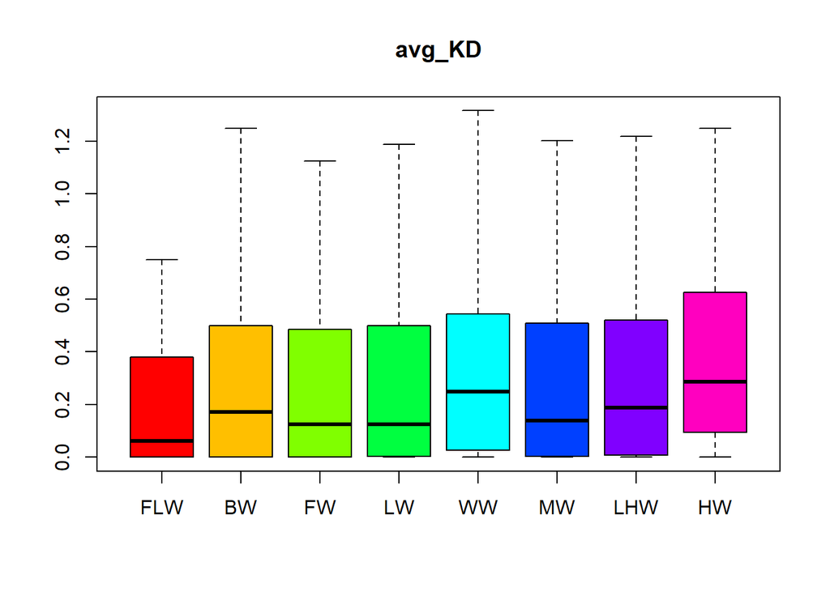

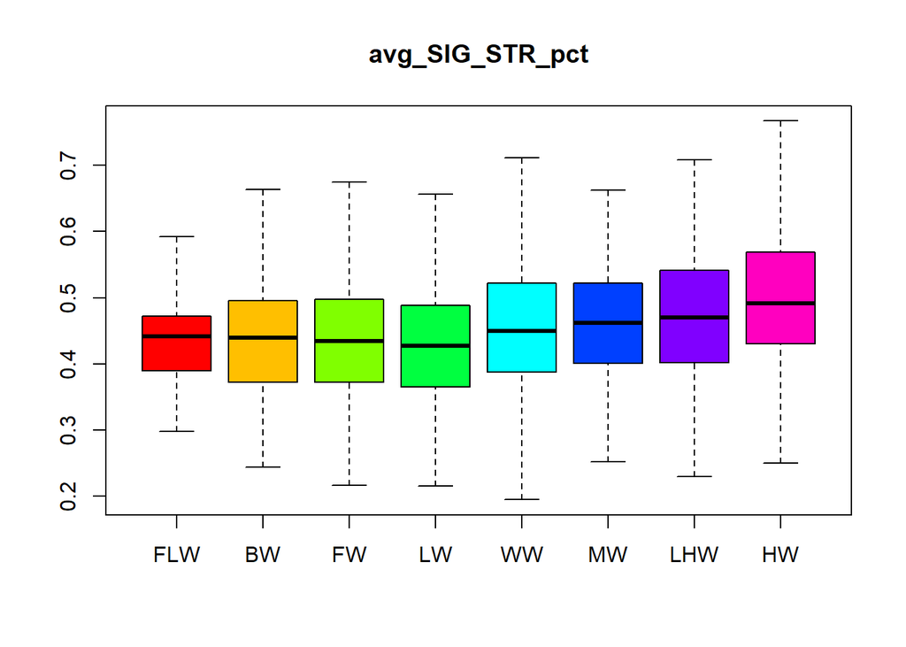

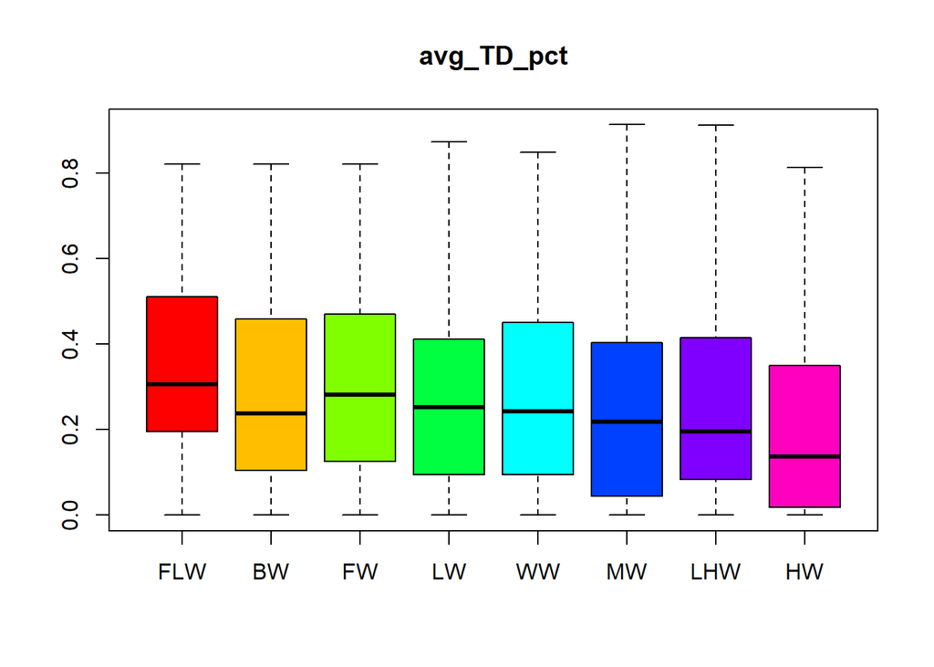

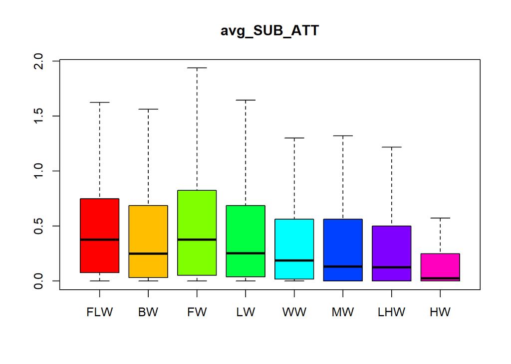

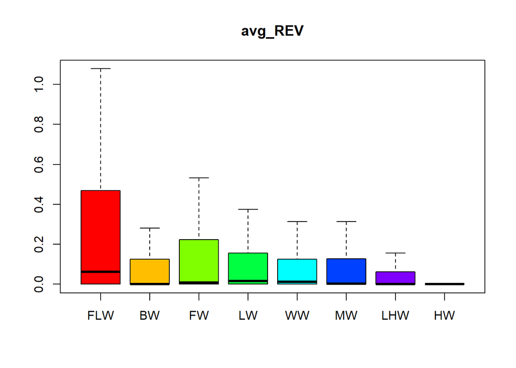

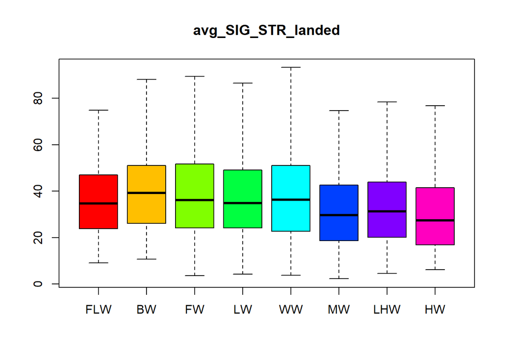

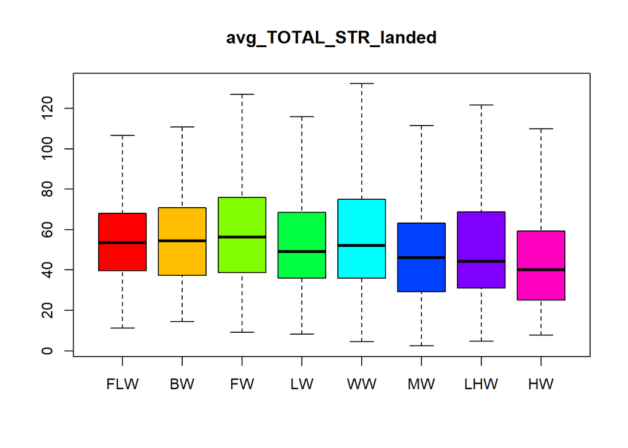

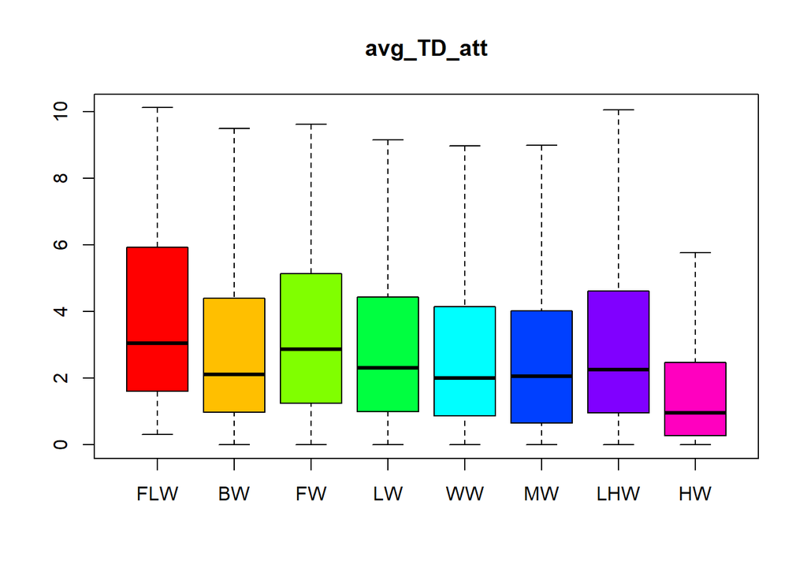

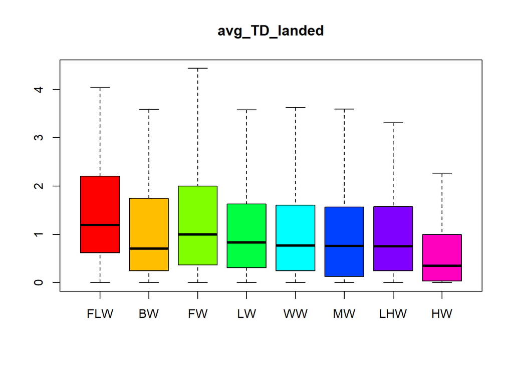

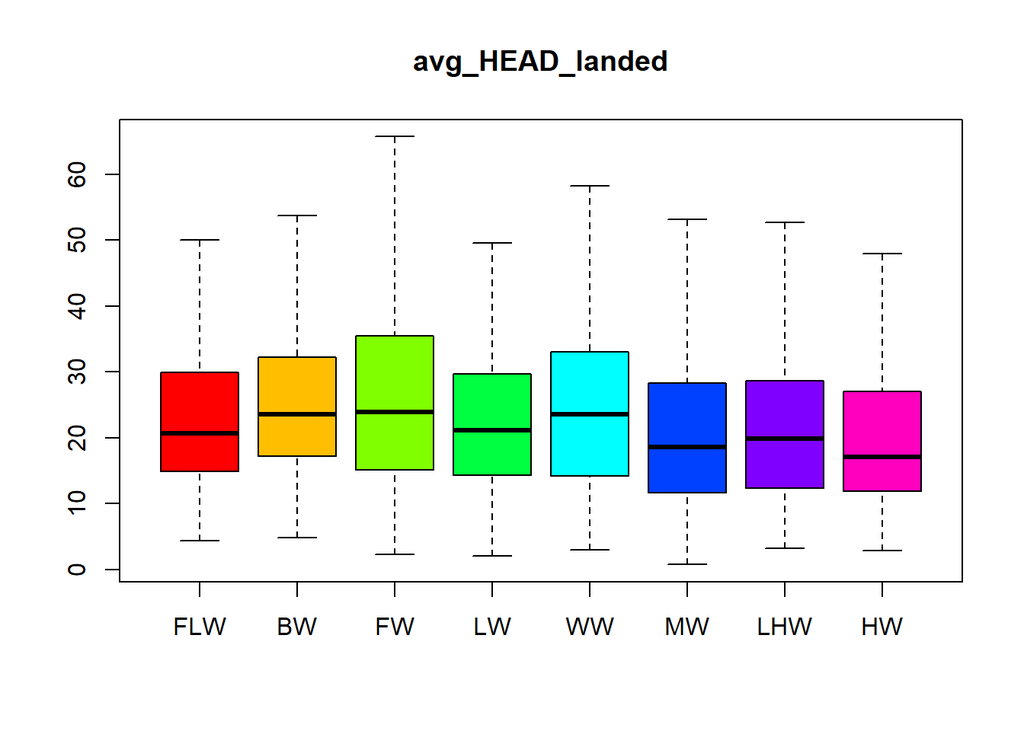

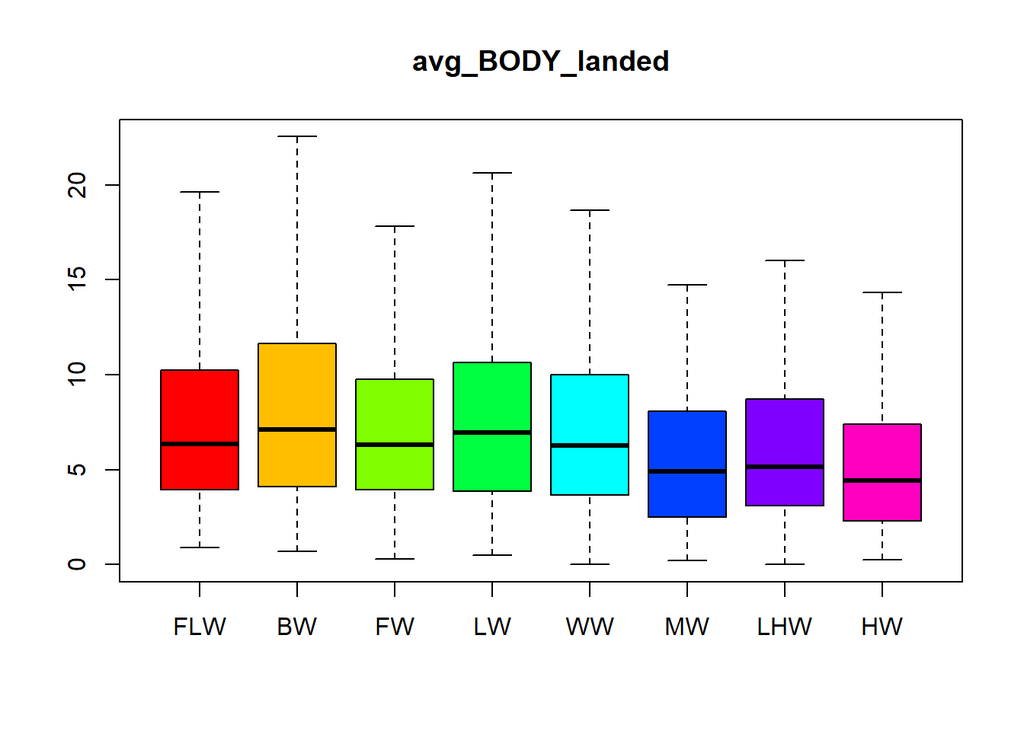

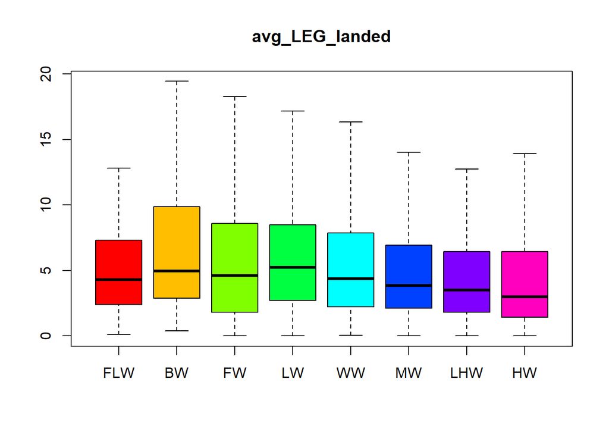

[12 more figures not shown]

```r
for(i in c(2:19, 33, 34, 36, 38:40)){
  boxplot(flw_stat[,i], bw_stat[,i], fw_stat[,i], lw_stat[,i], ww_stat[,i], mw_stat[,i], lhw_stat[,i], hw_stat[,i], main=colnames(fw_stat)[i], names=c("FLW", "BW", "FW", "LW", "WW", "MW", "LHW", "HW"), col=rainbow(8), outline=F)
}
```

From the side-by-side boxplots above, we can see a lot of interesting facts.

1. The stereotype that Heavyweight fighters barely grapple (wrestling, jiu-jitsu, etc) is real.

   We can see that Heavyweight has the lowest median in almost every stat related to grappling, including “*average takedown percentage*”, “*average submission attempt*”, “*average reverse*”, “*average takedown landed*”, “*average clinch strikes landed*”, “*average control time*” and “*win by submission percentage*”.

   Actually according to the plots, higher weight classes (Middleweight, LightHeavyweight, Heavyweight) generally seem to perform worse in grappling division.
2. The power of one fighter must have something to do with their weight.

   Firstly the concept that Heavyweight fighters have the most power in their hands is also true. We can see that Heavyweight has the highest “*average knockdown*” among all divisions. Moreover, Heavyweight has the highest “*win by KO/TKO percentage*” among all divisions (also has the lowest “*win by Decision percentage*”), actually it’s way higher than other weight classes, which mean Heavyweight fighters frequently end the fight by knocking out their opponents (that’s probably why they have the lowest “*average total time fought*” according to the plot).

   In contrast, Flyweight has the lowest “*average knockdown*” and the lowest “*win by KO/TKO percentage*” (highest “*win by decision percentage*” also), which means Flyweight fighters really don’t have enough power to hurt their opponent so that their fights also end in judge decision.

   Additionally, we can actually see in the boxplots that higher weight class has higher “*win by KO/TKO percentage*” and lower “*win by decision percentage*”, which further suggests the relationship between one’s weight and power.
3. The higher the weight class is, the taller the fighters are and the longer their reaches are. (This is actually a common sense)
4. There’s also a few counterintuitive findings. This first one is that while most people think that Heavyweight fighters are less skillful, they actually have the highest “*average significant strike percentage*”, which means they land their strikes more accurately than fighters in other weight class.

   Another finding is that the ages of Heavyweight fighters are actually the oldest among all weight classes. Many people think Heavyweight fighters usually have relatively shorter career than fighters in other division because they are facing more powerful opponents, but surprisingly the boxplot says the otherwise.

**Compare the stats between genders**

Now we want to see the difference between fighters with different gender. To eliminate the effect of the weight, we compare the pair of Bantamweight (men) and WomenBantamweight and the pair of Flyweight (men) and WomenFlyweight

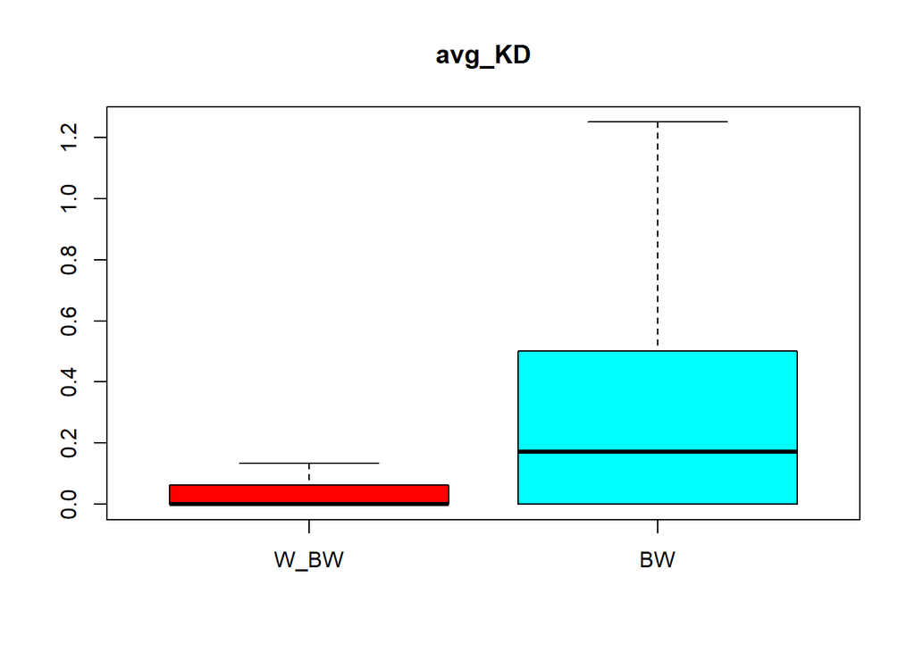

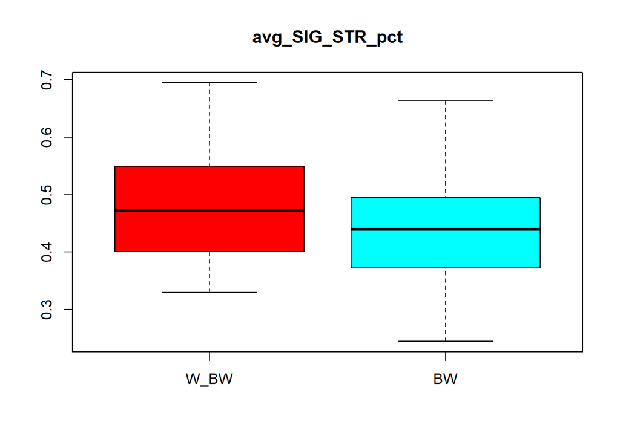

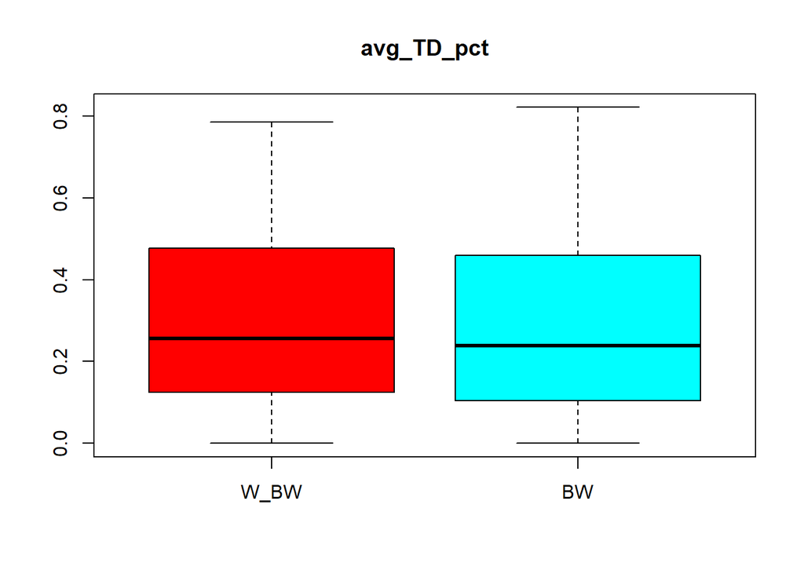

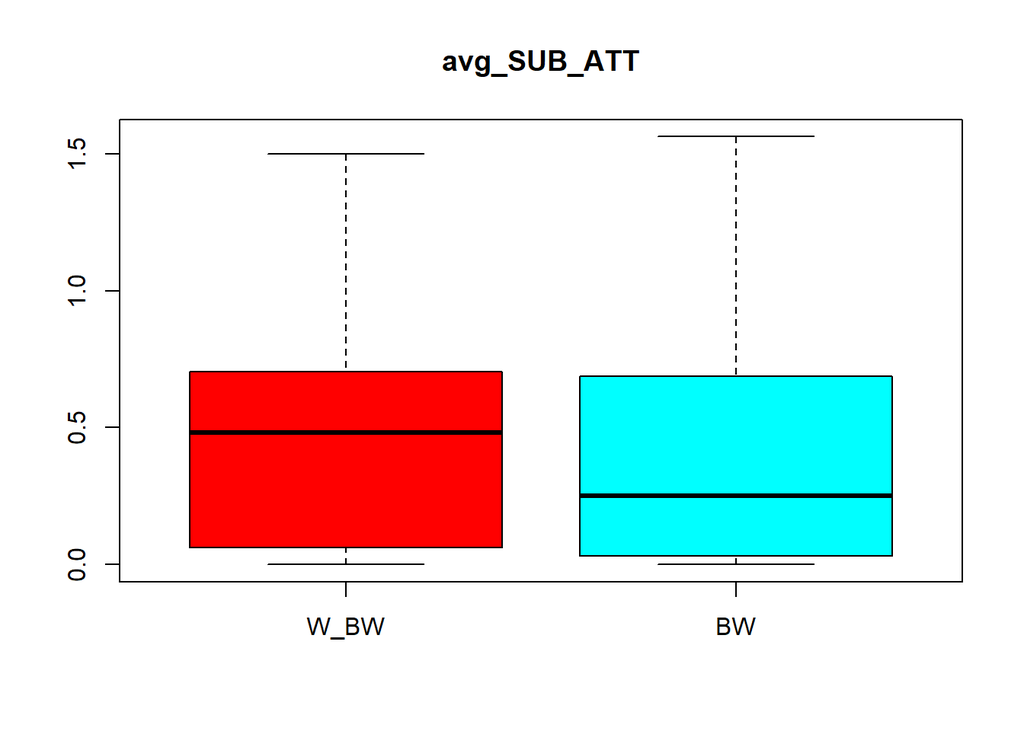

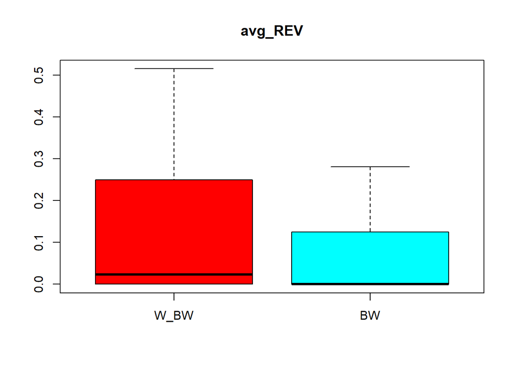

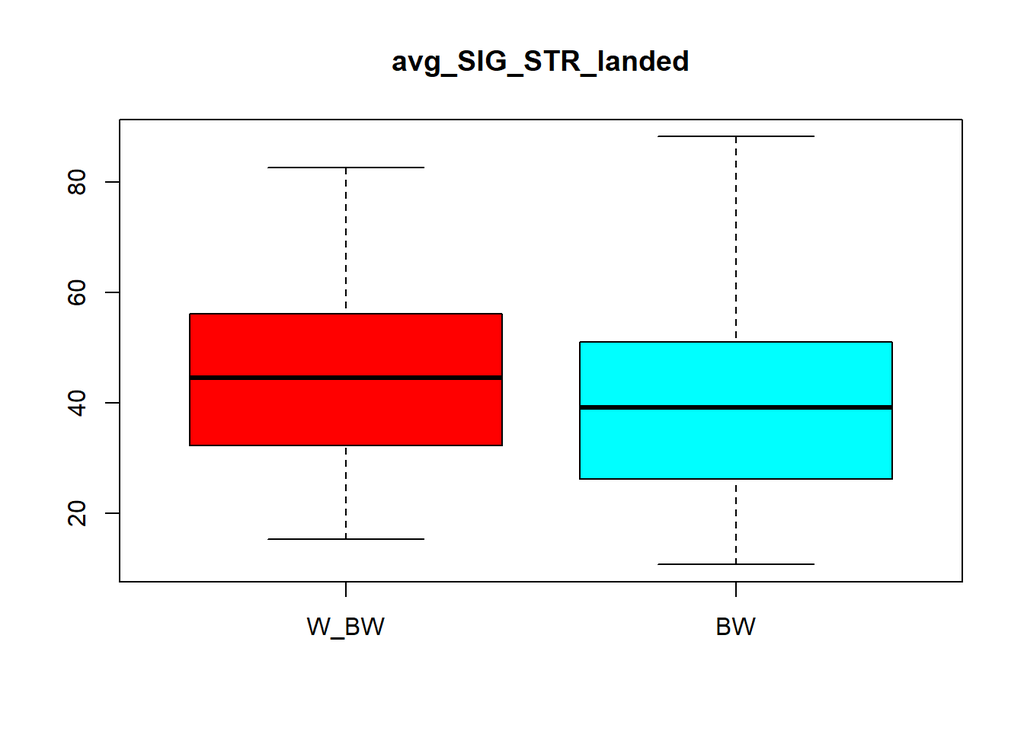

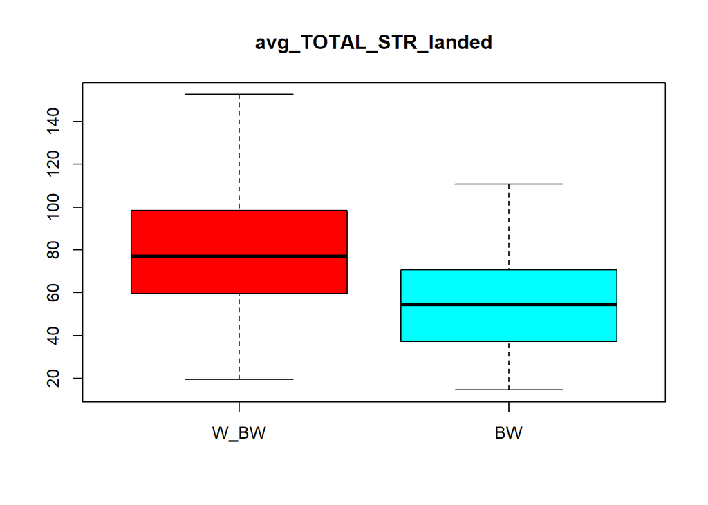

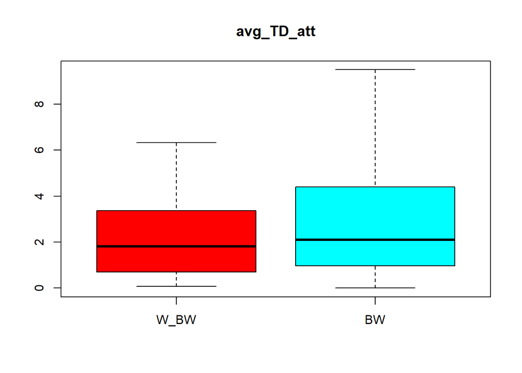

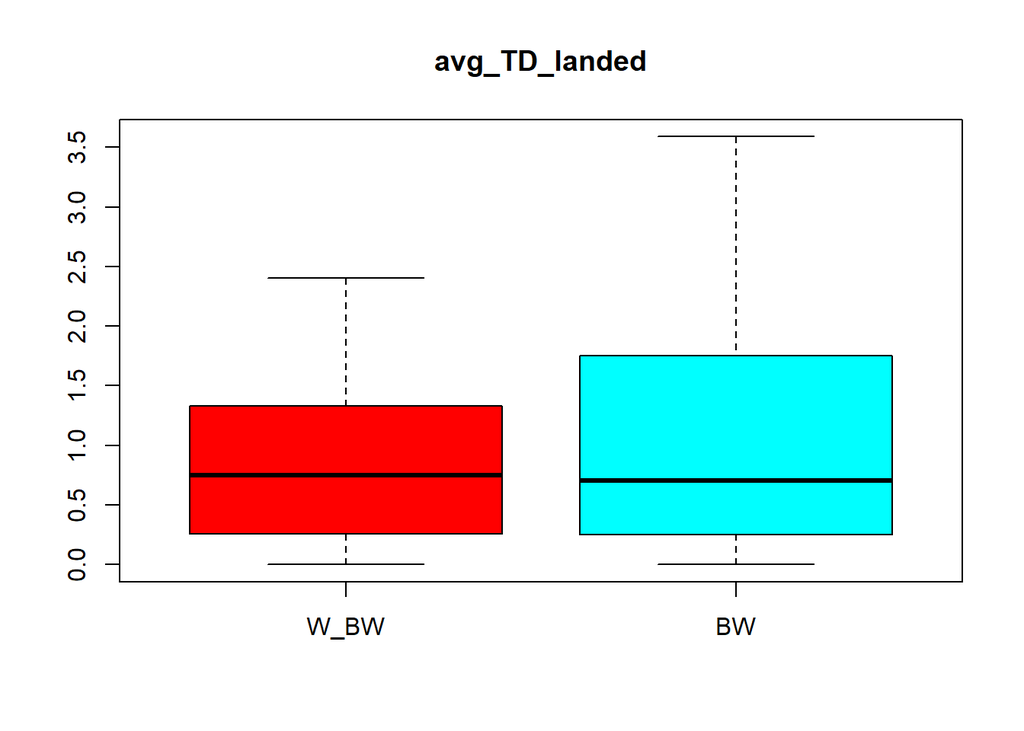

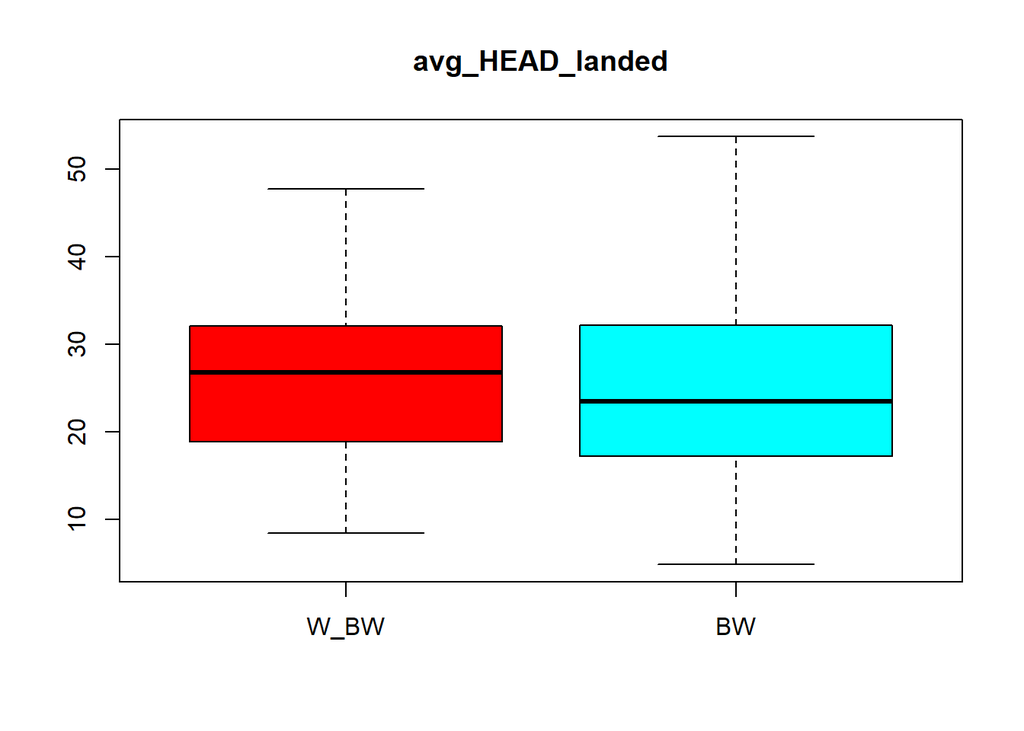

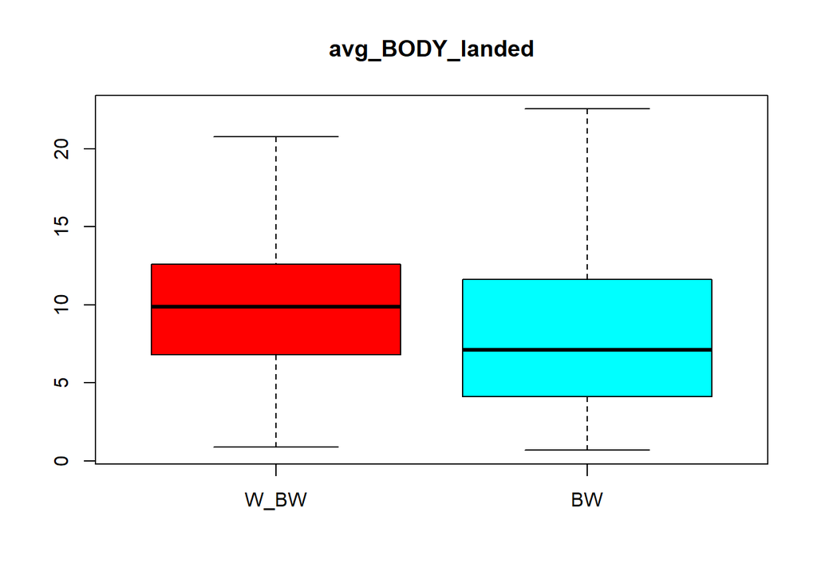

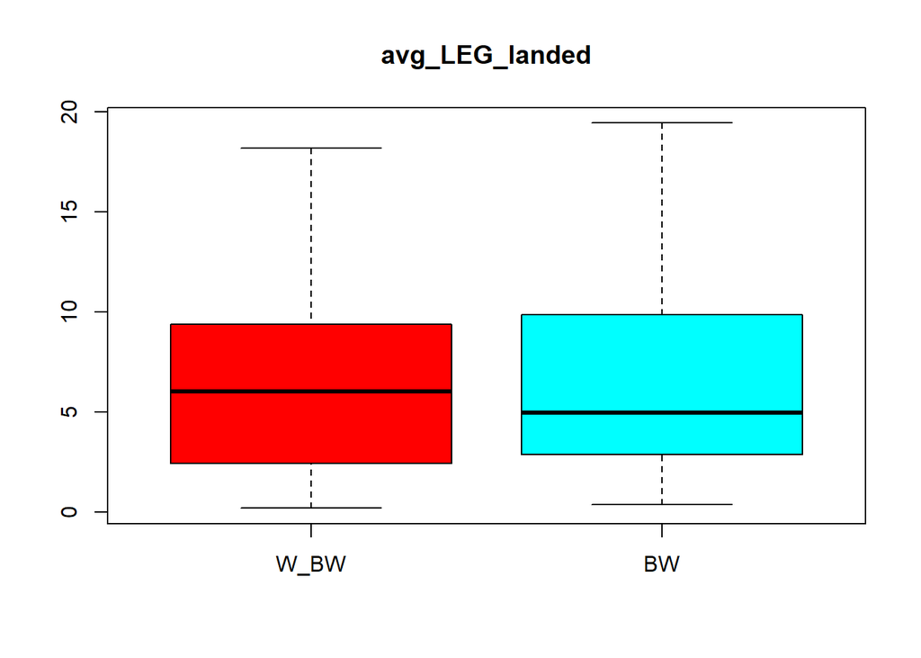

[12 more figures not shown]

```r
for(i in c(2:19, 33, 34, 36, 38:40)){
  boxplot(wbw_stat[,i], bw_stat[,i], main=colnames(fw_stat)[i], names=c("W_BW", "BW"), col=rainbow(2), outline=F)
}
```

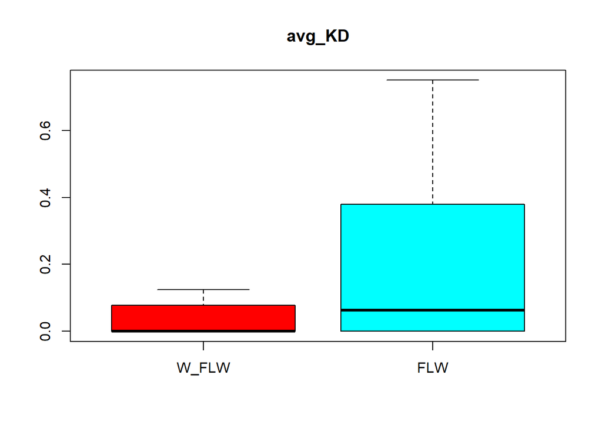

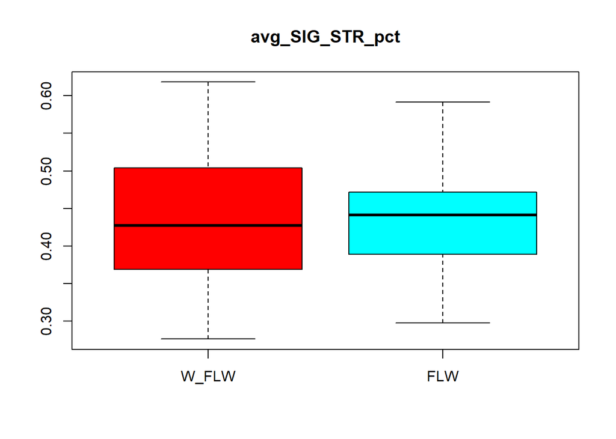

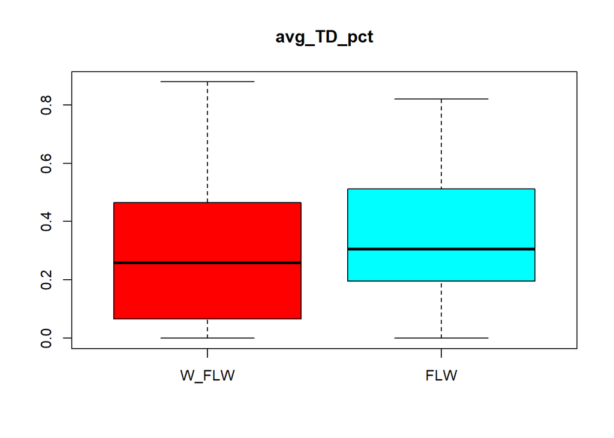

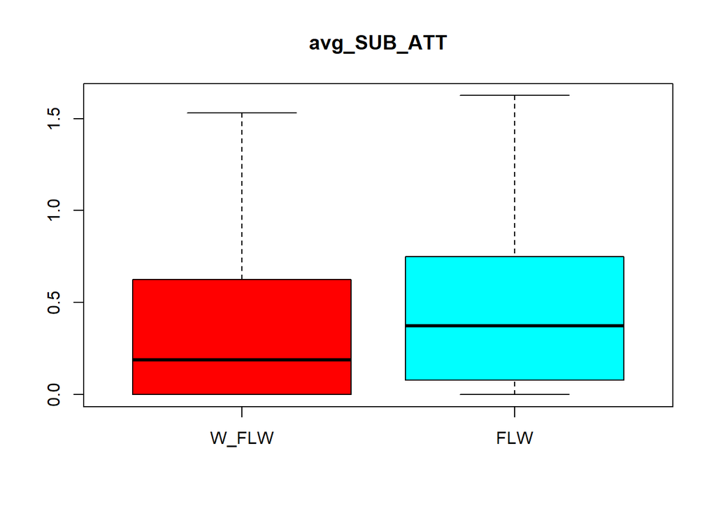

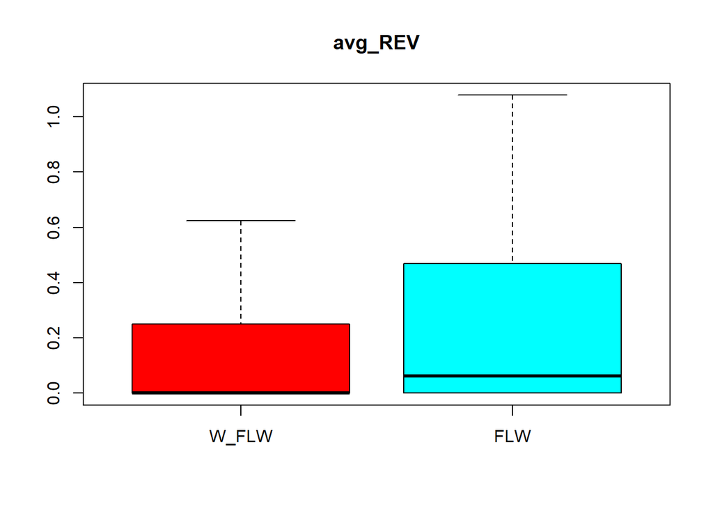

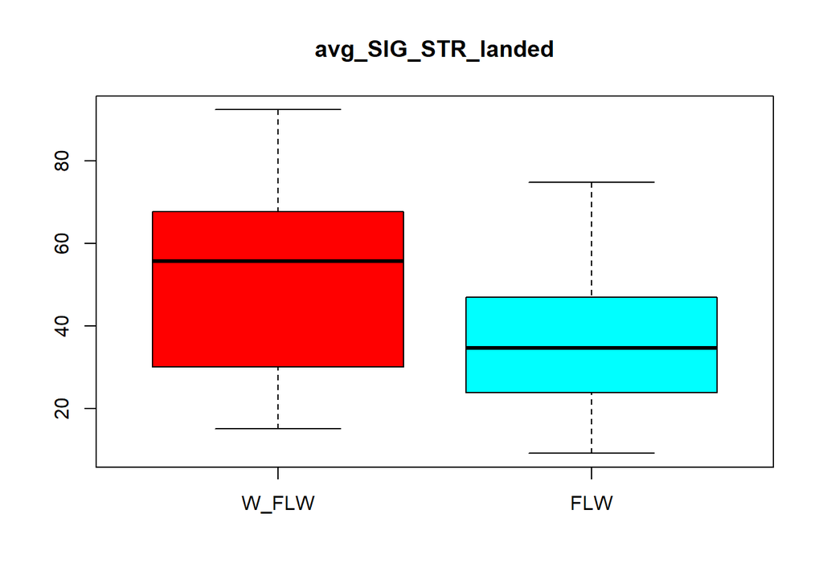

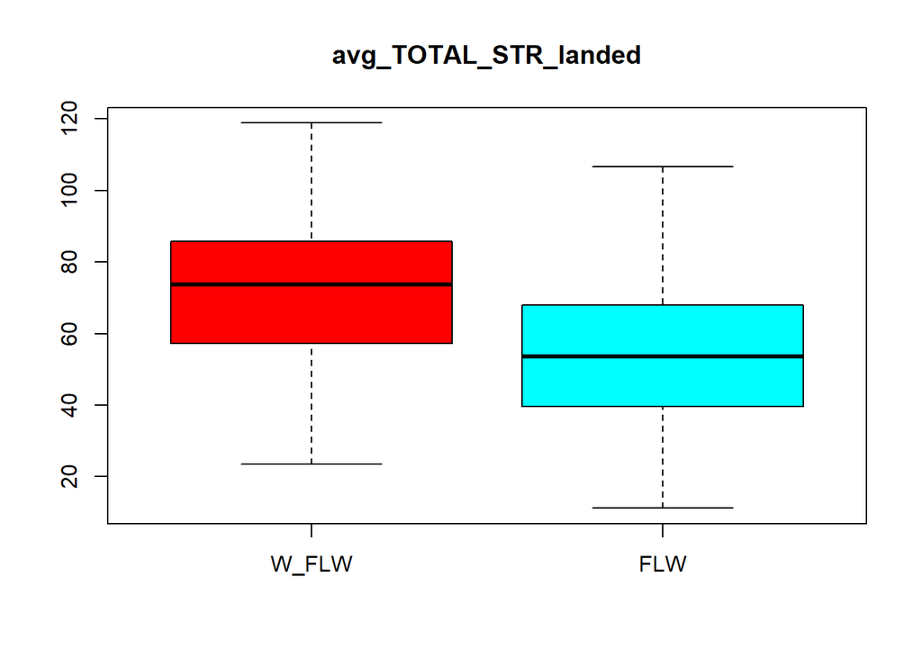

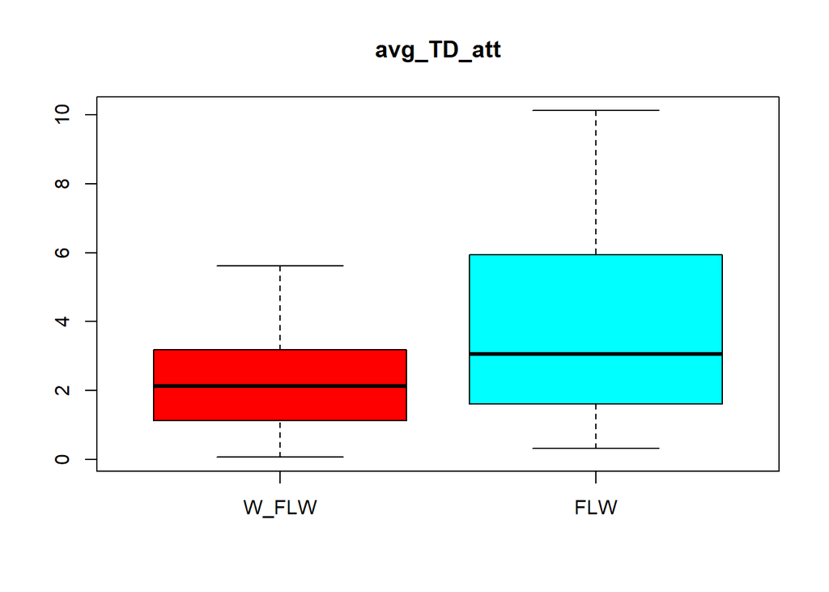

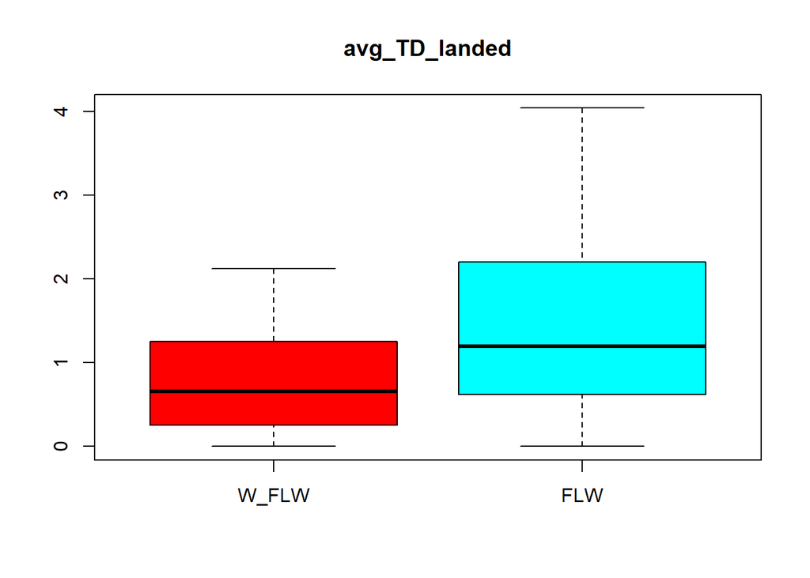

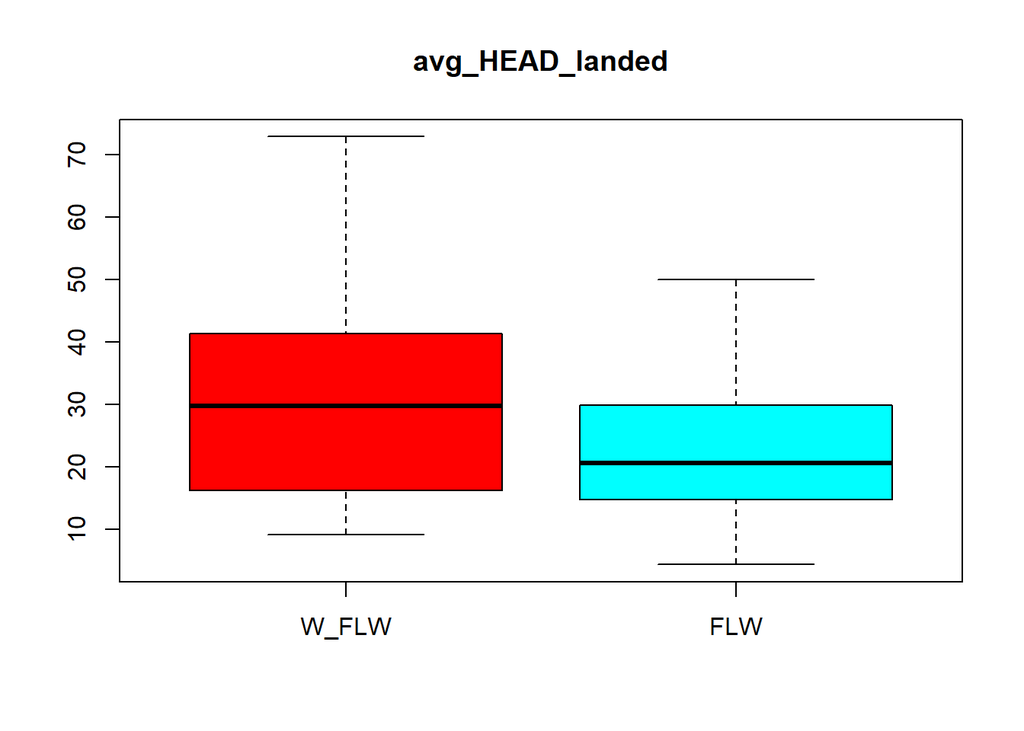

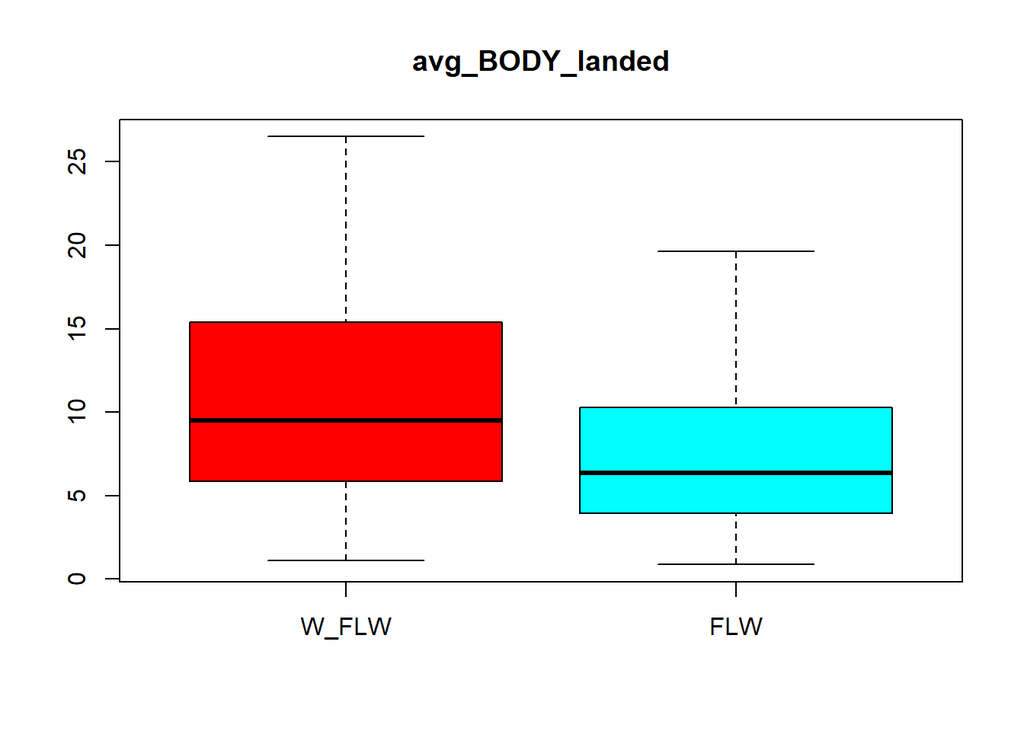

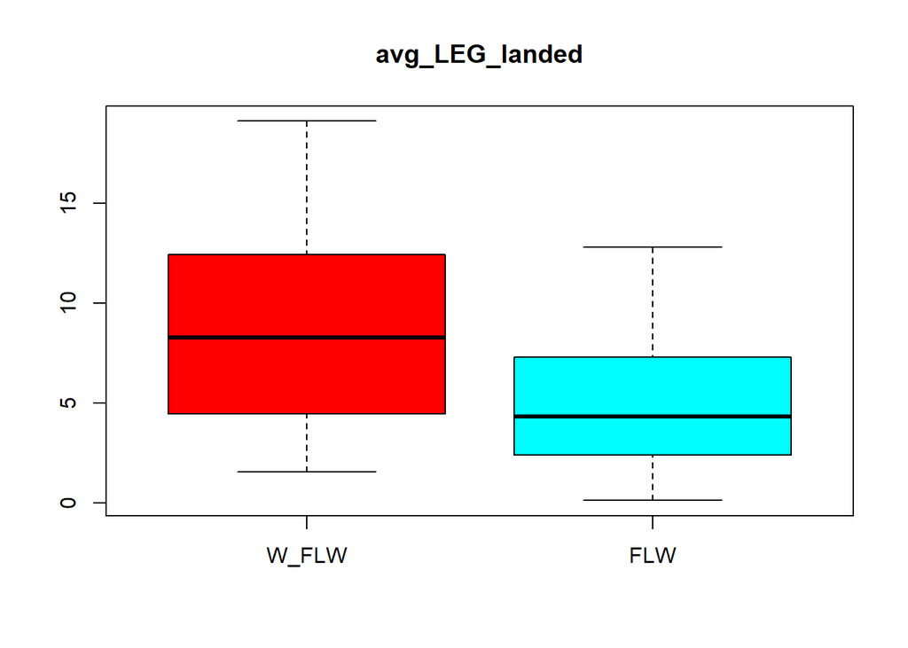

[12 more figures not shown]

```r
for(i in c(2:19, 33, 34, 36, 38:40)){
  boxplot(wflw_stat[,i], flw_stat[,i], main=colnames(fw_stat)[i], names=c("W_FLW", "FLW"), col=rainbow(2), outline=F)
}
```

According to the plots above, we can also see some interesting facts.

1. Male fighters generally are more powerful than female fighters.

   From the boxplots we can see that male fighters have higher “*average knockdown*” in both Flyweight and Bantamweight. Also, female fighters have higher “win by decision percentage” than male fighters in both weight classes, which means they generally lack the power to finish their opponets. That is probably why female fighters also have longer “average total time fought”.
2. Female fighters tend to throw more strikes than male fighters.

   From the boxplots we can see that females fighters have more “average strikes landed” in lmost every department, including significant strikes, head strikes, body strikes, leg strikes, etc.
3. Female fighters are generally older than male fighters.

   We can see that the median of “age” of female fighters are larger than male fighters in both weight classes.

**Check if there’s any other relationship between columns**

```r
cor = data.frame(cor(combine_data[, c(2:7, 10:19, 33, 34, 36, 38:40)]))
cor
```

```
##                                 avg_KD avg_SIG_STR_pct  avg_TD_pct  avg_SUB_ATT
## avg_KD                      1.00000000     0.146568414 -0.16698416 -0.177605654
## avg_SIG_STR_pct             0.14656841     1.000000000  0.15072917 -0.003597788
## avg_TD_pct                 -0.16698416     0.150729174  1.00000000  0.195924848
## avg_SUB_ATT                -0.17760565    -0.003597788  0.19592485  1.000000000
## avg_REV                    -0.10249078     0.006466969  0.07857879  0.248403185
## avg_SIG_STR_landed          0.02936338     0.085200541  0.05550326 -0.132895404
## avg_TD_landed              -0.20494605     0.111859263  0.61382775  0.147429961
## avg_HEAD_landed             0.05372589     0.057071278  0.07770047 -0.091914992
## avg_BODY_landed            -0.04310708     0.118649112  0.04481282 -0.097485900
## avg_LEG_landed              0.01366724     0.047943645 -0.04257942 -0.158499093
## avg_DISTANCE_landed         0.04564132    -0.061380040 -0.06957361 -0.165741420
## avg_CLINCH_landed          -0.06792077     0.205012518  0.08364333 -0.039132066
## avg_GROUND_landed           0.01618753     0.334692974  0.36021752  0.097295720
## avg_CTRL_time.seconds.     -0.23280460     0.187534809  0.50623611  0.226448994
## total_time_fought.seconds. -0.19408018    -0.149434414  0.16342361  0.009474842
## total_rounds_fought        -0.04480323    -0.042457254 -0.02316340 -0.078040428
## Height_cms                  0.12304700     0.118337752 -0.11196612 -0.100975156
## Reach_cms                   0.12292062     0.115460364 -0.07805931 -0.085556822
## age                        -0.03046871     0.062844610 -0.11321023 -0.166935631
## win_by_Decision_pct        -0.23071231    -0.122038852  0.13695006 -0.107018543
## win_by_KO.TKO_pct           0.43511583     0.179801245 -0.23651171 -0.294354744
## win_by_Submission_pct      -0.20744570    -0.056299429  0.10022167  0.441638675
##                                 avg_REV avg_SIG_STR_landed avg_TD_landed
## avg_KD                     -0.102490782         0.02936338  -0.204946048
## avg_SIG_STR_pct             0.006466969         0.08520054   0.111859263
## avg_TD_pct                  0.078578788         0.05550326   0.613827752
## avg_SUB_ATT                 0.248403185        -0.13289540   0.147429961
## avg_REV                     1.000000000        -0.05109160   0.051755995
## avg_SIG_STR_landed         -0.051091600         1.00000000   0.051723177
## avg_TD_landed               0.051755995         0.05172318   1.000000000
## avg_HEAD_landed            -0.019653675         0.91636105   0.079364008
## avg_BODY_landed            -0.048765942         0.73532252   0.006770080
## avg_LEG_landed             -0.090841449         0.59345677  -0.021646633
## avg_DISTANCE_landed        -0.075816205         0.92475459  -0.101593405
## avg_CLINCH_landed          -0.029441137         0.47498098   0.124594324
## avg_GROUND_landed           0.090231720         0.17764519   0.416397738
## avg_CTRL_time.seconds.      0.170626299         0.06142658   0.754374036
## total_time_fought.seconds.  0.079763759         0.62741359   0.287676408
## total_rounds_fought        -0.072357776         0.21687475   0.002779986
```

[output cut: 152 more lines]

```
## avg_HEAD_landed                     -0.178222391
## avg_BODY_landed                     -0.195520332
## avg_LEG_landed                      -0.198476434
## avg_DISTANCE_landed                 -0.196237851
## avg_CLINCH_landed                   -0.136703884
## avg_GROUND_landed                   -0.074114357
## avg_CTRL_time.seconds.               0.038315531
## total_time_fought.seconds.          -0.171346621
## total_rounds_fought                 -0.064088197
## Height_cms                          -0.011055672
## Reach_cms                            0.005536343
## age                                 -0.116093599
## win_by_Decision_pct                 -0.456939078
## win_by_KO.TKO_pct                   -0.439526516
## win_by_Submission_pct                1.000000000
```

We extract every correlation whose absolute value is larger than 0.4.

```r
v_names = rownames(cor)
for(i in 1:(nrow(cor)-1)){
  for(j in (i+1):(ncol(cor))){
    if(abs(cor[i, j]) >= 0.4 & !str_detect(v_names[i], regex("SIG"))){
      cat(sprintf("%s & %s: %f\n", rownames(cor)[i], colnames(cor)[j], cor[i, j]))
    }
  }
}
```

```
## avg_KD & win_by_KO.TKO_pct: 0.435116
## avg_TD_pct & avg_TD_landed: 0.613828
## avg_TD_pct & avg_CTRL_time.seconds.: 0.506236
## avg_SUB_ATT & win_by_Submission_pct: 0.441639
## avg_TD_landed & avg_GROUND_landed: 0.416398
## avg_TD_landed & avg_CTRL_time.seconds.: 0.754374
## avg_HEAD_landed & avg_BODY_landed: 0.496294
## avg_HEAD_landed & avg_DISTANCE_landed: 0.839328
## avg_HEAD_landed & total_time_fought.seconds.: 0.542825
## avg_BODY_landed & avg_LEG_landed: 0.428883
## avg_BODY_landed & avg_DISTANCE_landed: 0.645549
## avg_BODY_landed & avg_CLINCH_landed: 0.564065
## avg_BODY_landed & total_time_fought.seconds.: 0.494919
## avg_LEG_landed & avg_DISTANCE_landed: 0.606233
## avg_LEG_landed & total_time_fought.seconds.: 0.422666
## avg_DISTANCE_landed & total_time_fought.seconds.: 0.564325
## avg_GROUND_landed & avg_CTRL_time.seconds.: 0.581618
## total_time_fought.seconds. & win_by_Decision_pct: 0.440263
## Height_cms & Reach_cms: 0.895344
## win_by_Decision_pct & win_by_KO.TKO_pct: -0.570879
## win_by_Decision_pct & win_by_Submission_pct: -0.456939
## win_by_KO.TKO_pct & win_by_Submission_pct: -0.439527
```

After taking a quick look at the correlations above, we can easily see that many kinds of “*number of landed strikes*” are related to each other to some extent.

The interesting one is that “*average clinch strikes landed*” is only correlated with “*average body strikes landed*”, which means a fighter mostly attacks opponent’s body in the clinch position.

Now we remove the correlation between two kinds of “*number of landed strikes*” to get a clearer look at other correlations.

```r
v_names = rownames(cor)
reg_str = "STR|HEAD|BODY|LEG|DISTANCE|CLINCH|GROUND"
for(i in 1:(nrow(cor)-1)){
  for(j in (i+1):(ncol(cor))){
    if(abs(cor[i, j]) >= 0.4){
      if(!str_detect(v_names[i], regex(reg_str)) | !str_detect(v_names[j], regex(reg_str))){
        cat(sprintf("%s & %s: %f\n", rownames(cor)[i], colnames(cor)[j], cor[i, j]))
      }
    }
  }
}
```

```
## avg_KD & win_by_KO.TKO_pct: 0.435116
## avg_TD_pct & avg_TD_landed: 0.613828
## avg_TD_pct & avg_CTRL_time.seconds.: 0.506236
## avg_SUB_ATT & win_by_Submission_pct: 0.441639
## avg_SIG_STR_landed & total_time_fought.seconds.: 0.627414
## avg_TD_landed & avg_GROUND_landed: 0.416398
## avg_TD_landed & avg_CTRL_time.seconds.: 0.754374
## avg_HEAD_landed & total_time_fought.seconds.: 0.542825
## avg_BODY_landed & total_time_fought.seconds.: 0.494919
## avg_LEG_landed & total_time_fought.seconds.: 0.422666
## avg_DISTANCE_landed & total_time_fought.seconds.: 0.564325
## avg_GROUND_landed & avg_CTRL_time.seconds.: 0.581618
## total_time_fought.seconds. & win_by_Decision_pct: 0.440263
## Height_cms & Reach_cms: 0.895344
## win_by_Decision_pct & win_by_KO.TKO_pct: -0.570879
## win_by_Decision_pct & win_by_Submission_pct: -0.456939
## win_by_KO.TKO_pct & win_by_Submission_pct: -0.439527
```

1. The four variables, “*average takedown percentage*”, “*average takedown landed*”, “*average control time*”, “*average ground strikes landed*”, are correlated with one another to some extent. (Classic grappler)

   This is quite intuitive because if one have a high takedown percentage, one can take your opponent down easily, thereby having more takedowns in a fight. Also, since one can easily bring his opponent to the ground, he can control his opponent on the ground for longer time and land more ground strikes on his opponent.
2. “*Average knockdown*” are correlated with “*win by KO/TKO percentage*”.

   This also makes sense because if one can knock his opponent down easily, he’s more likely to knock his opponent out and ends the fight.
3. “*Average total time fought*” is correlated with several types of “*average landed strikes*”.

   This is nothing special because the more time one spends in a fight, the more strikes one can land on his opponent.
4. “*Average submission attempt*” is correlated with “*win by submission percentage*”.

   This one is also straightforward because the more submissions one attempts, the more likely he can submit his opponent and end the fight.
5. “*Average total time fought*” is correlated with “*win by decision percentage*”.

   The result of a fight is decided by judges when both fighters cannot finish each other before the time runs out. Therefore, the more time one spends in a fight, the more likely he fights for a full 15 minutes and then wins by decision.